# Final project

Lewis Zhang

2020/3/29

# Introduction and Motivation

Kobe Bryant, a titanic figure who inspired a generation of basketball players nationally and internationally, tragically died in a helicopter crash on Jan. 26. Bryant made his debut in 1996 at 18 and played 20 seasons for the Lakers before retiring. During his two-decade N.B.A. career, Kobe Bryant evolved into far more than an exceptional basketball player. He became a crucial conduit for the NBA league as it moved swiftly to expand its empire into an international enterprise.

[figure not shown]

And so, this is what the tragic passing of Bryant triggers a public outpouring of grief. The depth of a person and his life and how much he resonated in the world is sometimes quantified only in death. In those days, a lot of people around us, our friends, our relatives, our classmates, or colleagues, have also been mourning for Kobe, while many actually have not watched one of his games. Such a strange fact sparks my interest in studying how big Kobe Bryant’s influence is to the world. Obviously Kobe was so much more than an all-time great basketball player. He was also a Oscar winner, a writer, a philanthropist, a husband, and what he viewed as most important, a father. He was our generations’ Michael Jordan, and inspired countless adolescents to the point where you had to shout “Kobe” when throwing a piece of trash away.

[figure not shown]

Children played beside images of Kobe Bryant at the “House of Kobe” basketball court in the Philippines

After all, if anybody is interested in how big, specifically, Kobe Bryant has made influence in this world. Please hold on, I will show you all I what in a novel data analysis right away.

# Data manipulation

My data comes from our class survey. I selected 6 questions that are closely related to my topic. There is a question asking about the level of people’s shock(in a scale of 1-10) after they knew about Kobe’s death. Its shock scale will function as my response variable to indicate the degree of emotional impact that Kobe’s death has brought to people, and so reflect Kobe’s influence to different people with different backgrounds. I have indicators include whether you are a basketball fan, whether you are a US-citizen, whether you are a Chinese (I will explain why I selected this variable when we get to it), and whether you play sports, the four categorical variables. And, there is also a numerical variable which counts how many hours people watch sports per week. I will analyze them one by one.

```r
Prodata<-read.csv("Econ220DataS20_ano.csv")
# Create the empty variable for my edited dataset
myData <- NA

# Check question 76 about whether you watch basketball
prop.table(table(Prodata$q76)) # check if data needs cleaning
myData$basketball.fan<-Prodata$q76
# Check question 77 about your level of shocking after hearing Kobe's Death(1-10)
class(Prodata$q77) # check type
data.frame(table(Prodata$q77)) # check if data needs cleaning
summary(Prodata$q77) # view variable by function summary
myData$shock.scale<-as.numeric(Prodata$q77)

# Check question 42 about whether you are a Chinese
prop.table(table(Prodata$q42)) # check if data needs cleaning
myData$chineseBG<-Prodata$q42

# Check question 144 about whether you are a foreigner
prop.table(table(Prodata$q144)) # check if data needs cleaning
myData$foreigner<-Prodata$q144

# Check question 169 about how many hours you watch sports per week
class(Prodata$q169) # check type
data.frame(table(Prodata$q169)) # check if data needs cleaning
myData$watchsports<-Prodata$q169

# Check question 170 about whether you play sports
prop.table(table(Prodata$q170)) # check if data needs cleaning
myData$sportsFan<-Prodata$q170

# Convert myData to a data.frame
myData <- data.frame(myData)
```

# Graphs

## Histogram

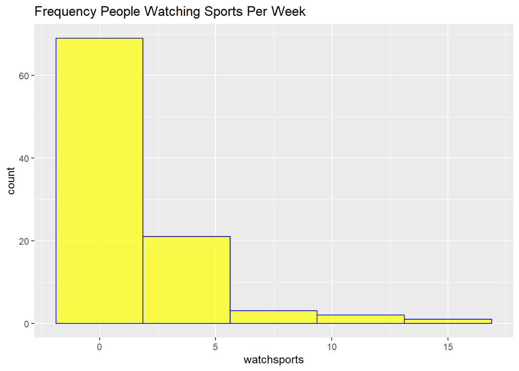

```r
myData %>% filter(!is.na(watchsports)) %>%
  ggplot(mapping=aes(watchsports)) + geom_histogram(fill="yellow", alpha=0.7, bins = 5, color="blue") + labs(title="Frequency People Watching Sports Per Week")
```

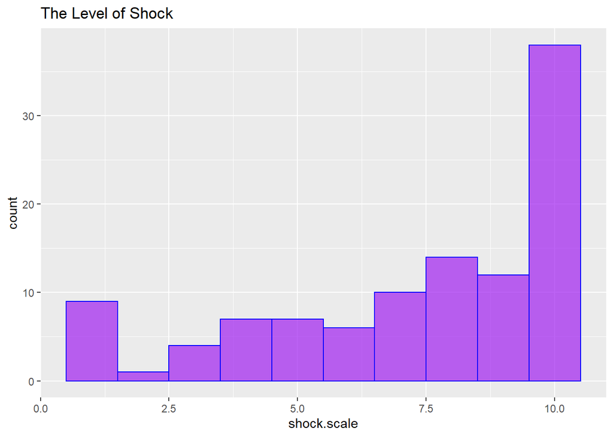

```r
ggplot(data=myData, mapping=aes(shock.scale)) + geom_histogram(fill="purple", alpha=0.7, bins = 10, color="blue") + labs(title="The Level of Shock")
```

Here are two histograms that present how long people spend on watching sports per week and how shock people are after hearing about Kobe Bryant’s death. The distribution of how long people spend on watching sports per week is intitive. It is a explicitly right-skewed and most of the observations fall within the leftmost bin, and the frequency gradually declines to the right.

However, the distribution of how shock people are after hearing about Kobe Bryant’s death is a bit unexpected. Generaly speaking, its shape looks very reasonable, but the considerable number of observations in the leftmost bin with the lowest scale surprises me. From the far right to the far left, it appears the frequency on the graph has a consistent pattern declining to the left, but the left most one breaks this pattern, bringing more fun in the process of analysis.

## Bar plot

I sketch these two bar plots to measure the average level of shock in different backgrounds of people. Given that the US is where Kobe Bryant started his career and made him a world-famous sports player, I want to know if Kobe’s influence in all other parts of the world is as widespread as what he has in the US. The first measurement I use is whether you are a foreigner in the US. I want to see if there is a difference in the emotional impact of Kobe’s death between the US people and the non-US people. The second measurement I use is whether you have Chinese background. I include this measurement because their is a question asking about whether you have Chinese background in our dataset and the proportion of people who have Chinese background seems considerable. Basketball is far more popular in China than in all the other countries outside the US. In that, China could be a outlier in the data that might pull up the entire average level significantly. So in order to examine if their is also a inconsistency regarding the emotional impact of Kobe’s death among other parts of the world, I sketch another barplot grouped by people’s Chinese background.

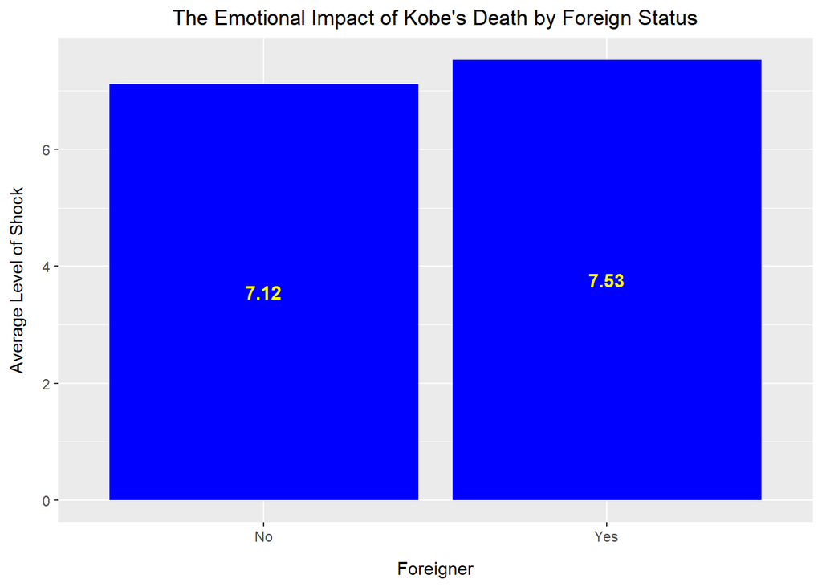

```r
myData %>%
  group_by(foreigner) %>%
  summarize(average_shock_scale=mean(shock.scale, na.rm=T)) %>%
  filter(!is.na(foreigner)) %>%
  ggplot(mapping=aes(y=average_shock_scale, x=foreigner, na.rm=T, label=round(average_shock_scale,2))) +
    geom_col(fill="blue") +
    geom_text(fontface=2, size=4, position=position_stack(vjust =.5), color="yellow") +
    ylab("Average Level of Shock") + xlab("Foreigner") +
    ggtitle("The Emotional Impact of Kobe's Death by Foreign Status") +
    theme(plot.title=element_text(hjust=0.5),
          axis.title.y=element_text(margin=margin(r=10)),
          axis.title.x=element_text(margin=margin(t=10)))
```

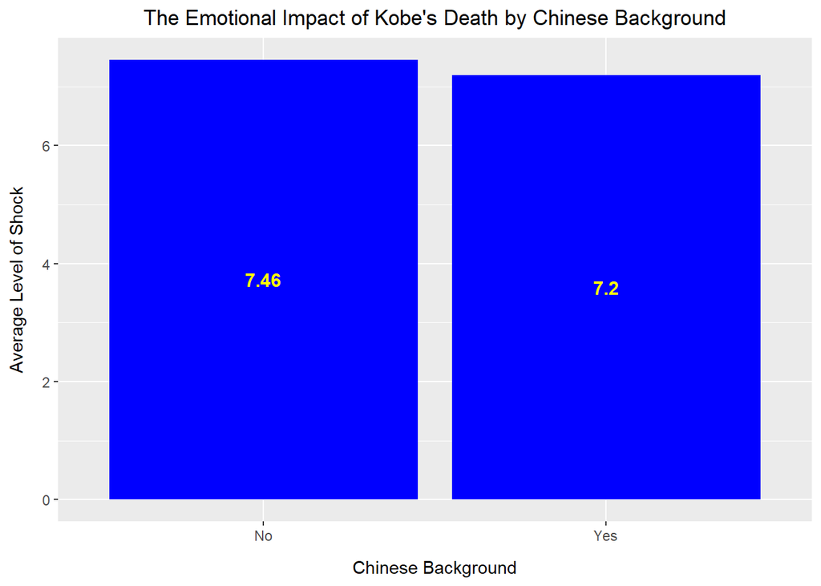

```r
myData %>%
  group_by(chineseBG) %>%
  summarize(average_shock_scale=mean(shock.scale, na.rm=T)) %>%
  filter(!is.na(chineseBG)) %>%
  ggplot(mapping=aes(y=average_shock_scale, x=chineseBG, na.rm=T, label=round(average_shock_scale,2))) +
    geom_col(fill="blue") +
    geom_text(fontface=2, size=4, position=position_stack(vjust =.5), color="yellow") +
    ylab("Average Level of Shock") + xlab("Chinese Background") +
    ggtitle("The Emotional Impact of Kobe's Death by Chinese Background") +
    theme(plot.title=element_text(hjust=0.5),
          axis.title.y=element_text(margin=margin(r=10)),
          axis.title.x=element_text(margin=margin(t=10)))
```

The results suprisinly vary from my anticipation. Before visualize the data, I thought the emotional impact of Kobe’s death among the US-people would be deeper than that among the non-US people, as the US is his homeland and is where he gains fame and fortune. No question Kobe has the most influence in the North America. However, the marked values of the average level of shock shows that Kobe’s death actually has more emotional impact among the the non-US people, though there is only a tiny difference between the two groups data. Interestingly, the result of the second graph reveals a similar pattern. It seems Chinese are less sentimental in response to Kobe’s death than all other people in the world. Given that our sample size is not very big, and there is not a substantial difference, probably this is purely by chance.

## Box plot

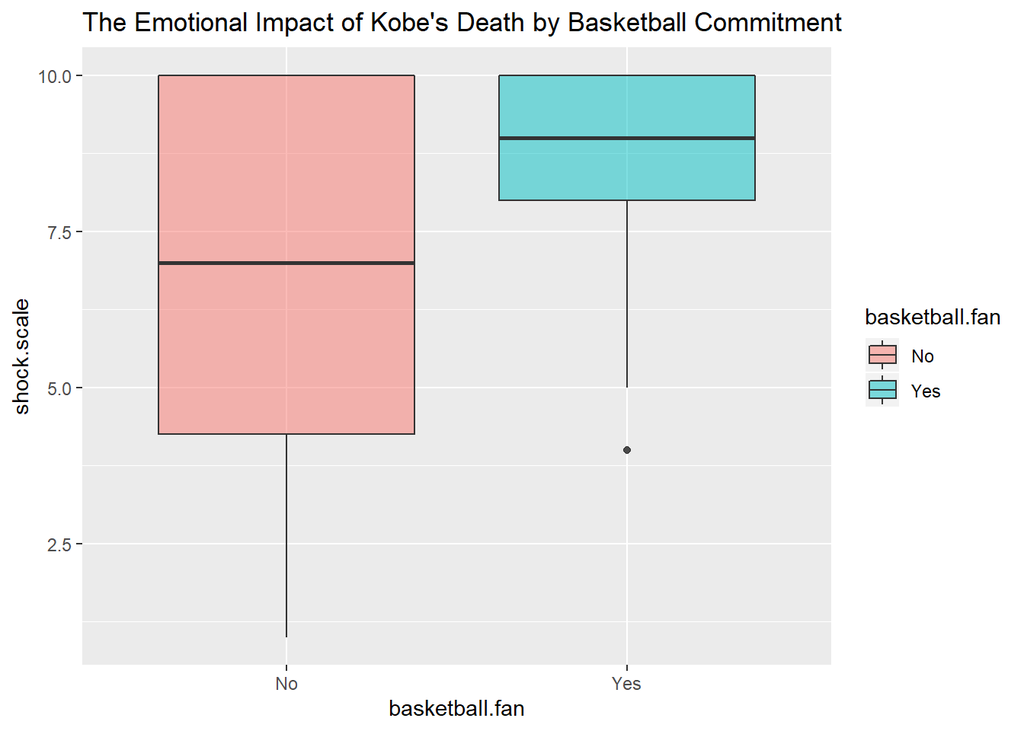

```r
myData %>%
  filter(!is.na(basketball.fan)) %>%
ggplot(mapping=aes(y=shock.scale, x=basketball.fan, fill=basketball.fan)) + geom_boxplot(alpha=0.5) + labs(title="The Emotional Impact of Kobe's Death by Basketball Commitment")
```

Above is a boxplot that examines the emotional impact of Kobe’s death by basketball commitment. “Basketball commitment” I mean if the person is a basketball fan. This time, I directly use the raw data of shock scales to indicate the emotional impact of Kobe’s death. The overall distributions of the two groups appears to have a notable difference. There is a huge gap between the median of shock scale in the basketball fan group and the median of shock scale in the non-basketball fan group. Such a discrepancy is noteworthy in data analysis. I am going to explore it in depth in the later inference section to test if the discrepancy in average level of shock between the two groups is statistically significant.

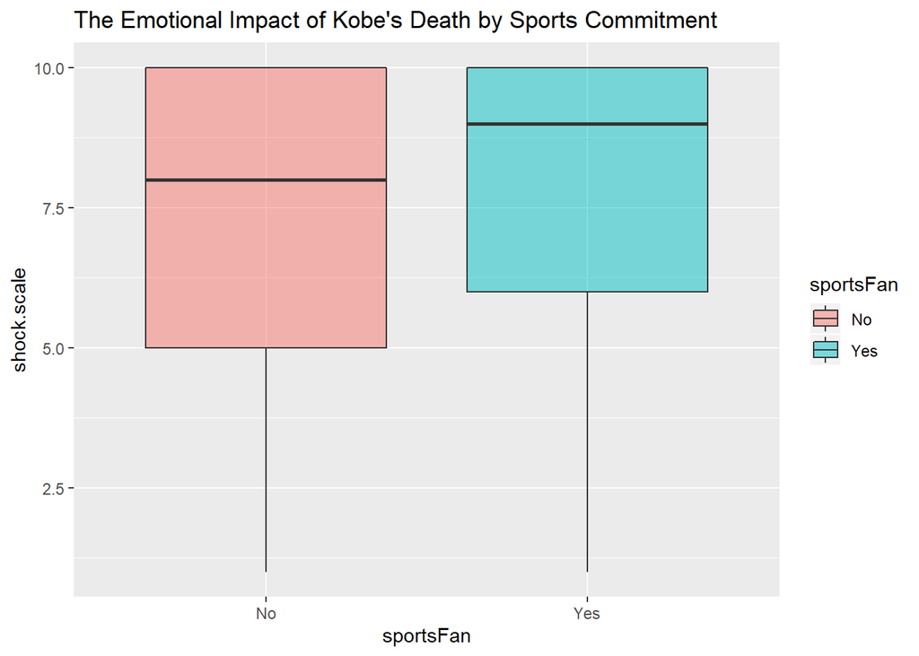

```r
myData %>%
  filter(!is.na(sportsFan)) %>%
ggplot(mapping=aes(y=shock.scale, x=sportsFan, fill=sportsFan)) + geom_boxplot(alpha=0.5) + labs(title="The Emotional Impact of Kobe's Death by Sports Commitment")
```

## Correlation Analysis

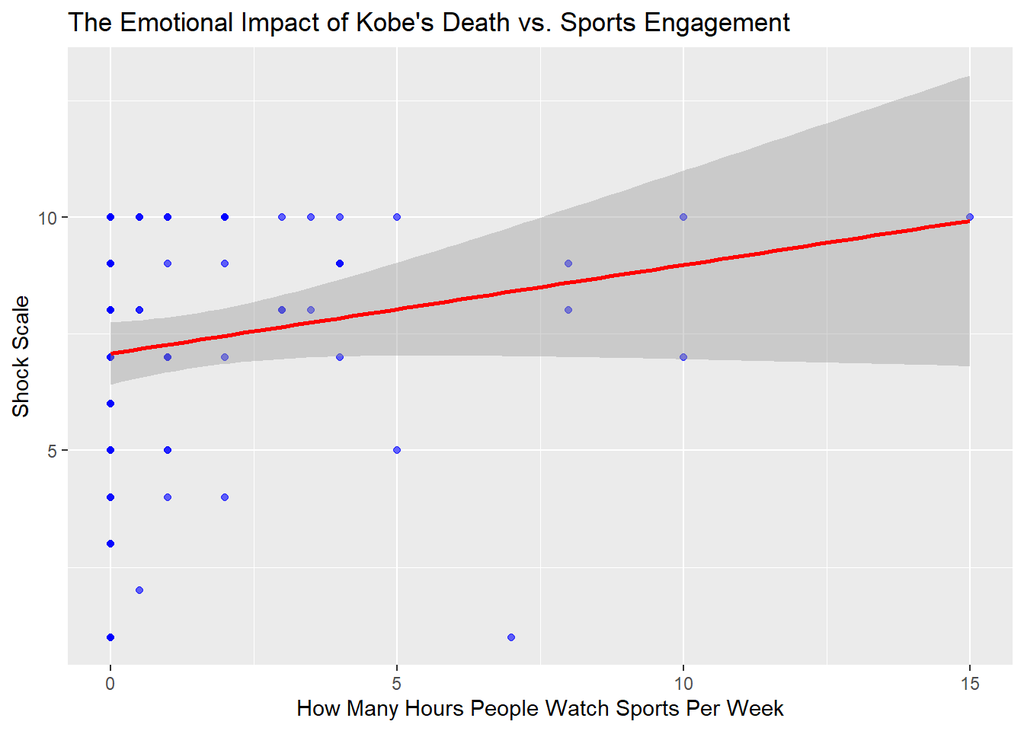

```r
myData %>%filter(!is.na(watchsports)) %>% ggplot(mapping=aes(y=shock.scale,x=watchsports)) + geom_point(alpha=0.6, color="blue") + labs(title="The Emotional Impact of Kobe's Death vs. Sports Engagement") + geom_smooth(method="lm", alpha = 0.4, color="red") + xlab("How Many Hours People Watch Sports Per Week")+
  ylab("Shock Scale")
```

Now I sketch a scatter plot to to measure the correlation between the emotional impact that Kobe’s death brought to people and their sports engagement. Again, I use the shock scale records to reflect people’s reaction after they knowing about Kobe’s death. While for the independent variable, I use a new one which counts how many hours people watch sports per week to represent their weekly sports engagement. The above linear model reveals a postive weak correlation between these two varaibles. If you scroll down the page, you will see the correlation is explicit presented in a table.

```r
myData%>% filter(!is.na(watchsports))%>%
  select(watchsports, shock.scale)%>% #to select mode and valence
  cor()%>% #to obtain the correlation between the two selected variables
  kable(type="html",digits=3)%>%
  kable_styling(bootstrap_options="responsive",full_width=F)%>% #aesthetic purposes only
    column_spec(1,bold=T)%>% #to bold the first column
  add_header_above(c("Correlation"=3)) #to add a header above all three columns
```

| Correlation | Correlation watchsports | Correlation shock.scale |
| --- | --- | --- |
| watchsports | 1.00 | 0.17 |
| shock.scale | 0.17 | 1.00 |

Here the correlation between the shock level of people after they heard about the tragedy and their regular sports engagement is nicely formatted in a table. The result is consistent with our estimate from the scatter plot. Indeed, there is only a weak correlation between the emotional impact that Kobe’s death brought to people and their sports engagement.

# Inference

```r
t.test(shock.scale ~ basketball.fan, data = myData)
```

```
##
##  Welch Two Sample t-test
##
## data:  shock.scale by basketball.fan
## t = -4.0903, df = 105.35, p-value = 8.447e-05
## alternative hypothesis: true difference in means is not equal to 0
## 95 percent confidence interval:
##  -2.913659 -1.011153
## sample estimates:
##  mean in group No mean in group Yes
##          6.642857          8.605263
```

```r
t.test(shock.scale ~ sportsFan, data = myData)
```

```
##
##  Welch Two Sample t-test
##
## data:  shock.scale by sportsFan
## t = -1.1307, df = 95.246, p-value = 0.261
## alternative hypothesis: true difference in means is not equal to 0
## 95 percent confidence interval:
##  -1.7936911  0.4918729
## sample estimates:
##  mean in group No mean in group Yes
##          7.040000          7.690909
```

The first Two Sample t-test tests the claim that if the emotional impact of Kobe’s death is greater to basketball fans than to non-baskeball fans. The result shows the t statisic -4.0903 is quite big, and the p-value 8.447e-05 is quite small. The null hypothesis in this test is that the true difference is equal to 0, while the alternative hypothesis suggets it is not equal to zero. In a 95 percent confidence interval, the difference is between -2.913659 and -1.011153. Number 0 is far away from the interval, so it is highly unlikely that the true mean differecne is equal to zero. Therefore, we can reject the null hypothesis, and we can conclude that there is a statistically siginifciant difference in the emotional impact of Kobe’s death between basketball fans and non-basketball fans.

The second Two Sample t-test tests the claim that if the emotional impact of Kobe’s death is greater to sports fans than to non-sports fans. The result shows the t statisic -1.1307 is not big, and the p-value 0.261 is quite likely. The null hypothesis in this test is that the true difference is equal to 0, while the alternative hypothesis suggets it is not equal to zero. In a 95 percent confidence interval, the difference is between -1.7936911 and 0.4918729. Number 0 falls within the interval, so it is likely that the true mean differecne is equal to zero. Therefore, we fail to reject the null hypothesis, and we can conclude that there is a not statistically siginifciant difference in the emotional impact of Kobe’s death between sports fans and non-sports fans.

# Conclusion

The hypothesis test does indicate Kobe’s influence towards basketball fan is much higher than his influence towards non-baskeball fan, but the difference of his influence between sports fan and non-sports fan is not statistically significant. Based on this result, I am afraid I have to point out that there is still a gap between the influence Kobe brought to basketball world and he brought to other parts of the world. Of course, he was and will always be one of the greatest player in NBA history, and his mentality will always be remembered by our generaton and the generation after generation. This project, basically, is my personal dedication to Kobe and to the whole world of people who love him and the people who love this sport becasue of him.

Admittedly, if our sample size is larger, it could be more representative. But I believe the most significant bias in our sample is that all the respondents are students. This could consequently distort our research result. For example, my generation were growing up along watching Kobe’s game, so Kobe has had an overwhelming influence to our generation, but this might not be the story to our parents or grandparents. This bias could create a over-estimate in my test result. If I want to generalize my finding, I have got to acquire a more comprehensive sample.

# Reference

https://time.com/5771924/kobe-bryant-obituary/

https://bleacherreport.com/articles/10169-kobe-bryant-makes-a-difference-beyond-the-court

https://sports.yahoo.com/kobe-bryants-influence-entire-world-175514573.html